# Spatial statistics - Assignment 3

Edgar Manrique

4/26/2022

1. Suppose that the mean annual temperature for a location was uniformly distributed, between 10°C and 18°C, implying that in each year any temperature in this range is equally likely to be the mean for the year. (Note: This is an unrealistic example, in the sense that mean temperatures are not likely to have this kind of distribution.)
1. What is the probability that the mean annual temperature is between 12°C and 15°C (see slide Uniform Distribution)?

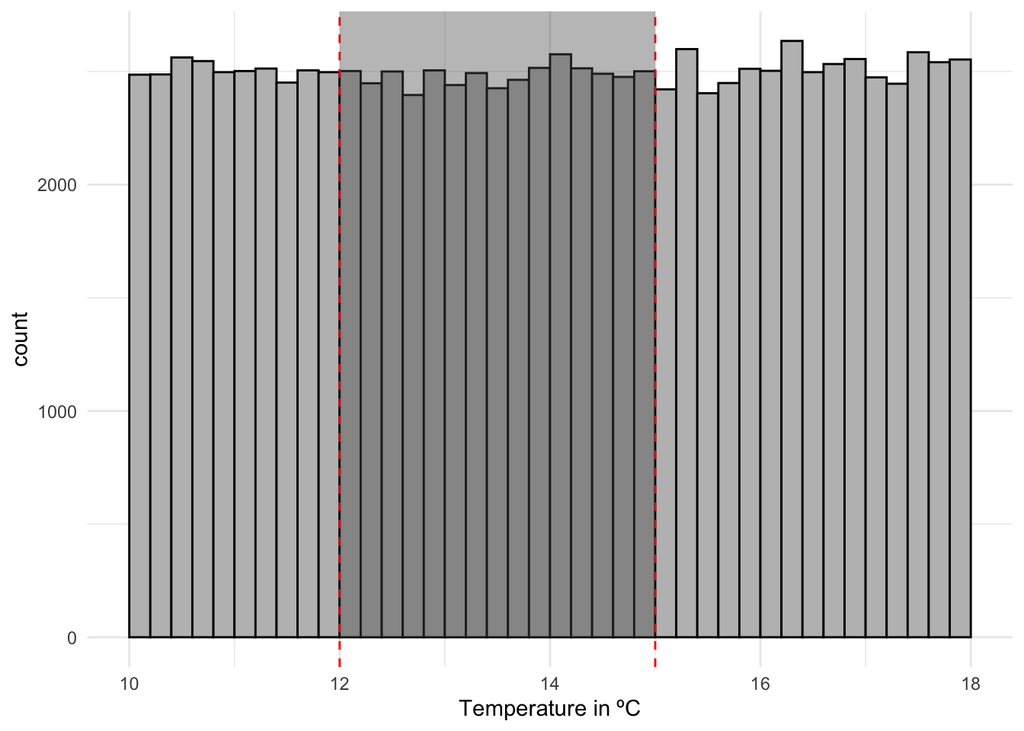

```r
set.seed(2)
x <- data.frame(x = runif(n = 99999, min = 10, max = 18))
x |>
ggplot() +
  geom_histogram(aes(x = x), fill = 'gray', col = 'black', binwidth = .2, center = .1) +
  geom_vline(xintercept = 12, color = 'red', linetype = 'dashed') +
  geom_vline(xintercept = 15, color = 'red', linetype = 'dashed') +
  annotate("rect", xmin = 12, xmax = 15, ymin = 0, ymax = Inf, alpha = .4) +
  theme_minimal() +
  labs(x = 'Temperature in ºC')
```

```r
l <- 18 - 10
h <- 1/(18-10)

l2 <- 15 - 10
l1 <- 12 - 10

a2 <- h*l2
a1 <- h*l1

p <- a2-a1
p
```

```
## [1] 0.375
```

- The probability that the mean annual temperature is between 12°C and 15°C is 37.5%.
2. What is the probability that the mean annual temperature is extreme in one year (below 10.5°C or above 17.8°C)?

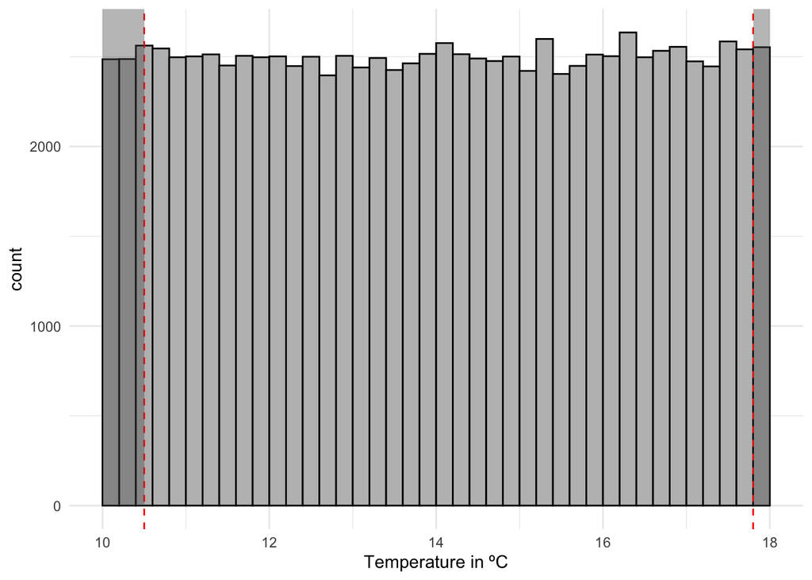

```r
set.seed(2)
x <- data.frame(x = runif(n = 99999, min = 10, max = 18))
x |>
ggplot() +
  geom_histogram(aes(x = x), fill = 'gray', col = 'black', binwidth = .2, center = .1) +
  geom_vline(xintercept = 10.5, color = 'red', linetype = 'dashed') +
  geom_vline(xintercept = 17.8, color = 'red', linetype = 'dashed') +
  annotate("rect", xmin = 10, xmax = 10.5, ymin = 0, ymax = Inf, alpha = .4) +
  annotate("rect", xmin = 17.8, xmax = 18, ymin = 0, ymax = Inf, alpha = .4) +
  theme_minimal()+
  labs(x = 'Temperature in ºC')
```

```r
l2 <- 18 - 17.8
l1 <- 10.5 - 10

a2 <- h*l2
a1 <- h*l1

p <- a2 + a1
p
```

```
## [1] 0.0875
```

- the probability that the mean annual temperature is extreme is 8.75%.
2. If commuting times are normally distributed with mean 30 minutes, and standard deviation 16 minutes, find the probability that a commute is shorter than 35 minutes. Use the table attached.

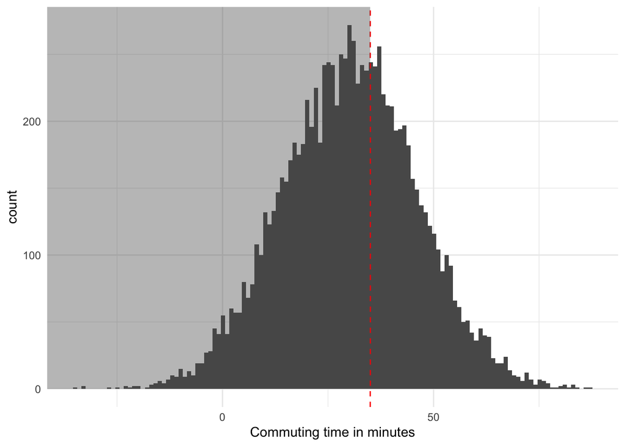

```r
set.seed(2)
x <- data.frame(x = rnorm(n = 9999, mean = 30, sd = 16))

x |>
  ggplot() +
  geom_histogram(aes(x = x), binwidth = 1, center = .1) +
  geom_vline(xintercept = 35, color = 'red', linetype = 'dashed') +
  annotate("rect", xmin = -Inf, xmax = 35, ymin = 0, ymax = Inf, alpha = .4) +
  theme_minimal()+
  labs(x = 'Commuting time in minutes')
```